# Check results for Acantharea

Author

Thelma Panaïotis

Acantharea were found to be much closer than expected under a random distribution. Let’s check if these could be the result of an artifact of any kind. More specifically, we’ll checked that observed distances are not caused by just a few very dense patched, and that objects identified as Acantharea are indeed Acantharea.

## Read data

Let’s start by reading data and selecting only Acantharea.

```r
# Read plankton
plankton <- read_parquet("data/00.plankton_clean.parquet")

# Keep only Acantharea
plankton <- plankton %>% filter(taxon == "Acantharea")

# Read images
images <- plankton %>% select(transect, img_name, datetime, lat, lon, depth) %>% distinct()
```

## Check for potential clusters of Acantharea

### Where are high density of Acantharea?

First, to detect potential clusters, we need to count Acantharea per image. Then plot it for each transect.

```r
# Count Acantharea per image
counts <- plankton %>% count(transect, img_name)
counts %>% arrange(desc(n))
```

```
# A tibble: 111,307 × 3
   transect         img_name                       n
   <chr>            <chr>                      <int>
 1 cross_current_02 2013-07-24_03-37-20_389060    76
 2 cross_current_02 2013-07-24_03-36-52_503210    75
 3 cross_current_02 2013-07-24_03-37-07_131810    75
 4 cross_current_02 2013-07-24_03-37-17_097625    74
 5 cross_current_02 2013-07-24_03-37-11_886105    72
 6 cross_current_02 2013-07-24_03-36-45_188910    69
 7 cross_current_02 2013-07-24_03-36-49_943205    69
 8 cross_current_02 2013-07-24_03-36-55_428930    69
 9 cross_current_02 2013-07-24_03-37-16_366195    68
10 cross_current_02 2013-07-24_03-37-18_926200    68
# ℹ 111,297 more rows
```

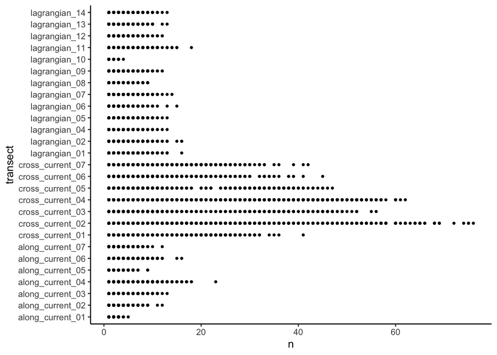

```r
# Look at number of Acantharea per image for each transect
ggplot(counts) +
  geom_point(aes(x = n, y = transect), size = 0.8) +
  scale_x_continuous() +
  theme_classic()
```

Images with many Acantharea (i.e. potential clusters) are found in cross current transects.

### Does this affect Acantharea distances?

Let’s now check whether there is a difference in distance distribution across transects.

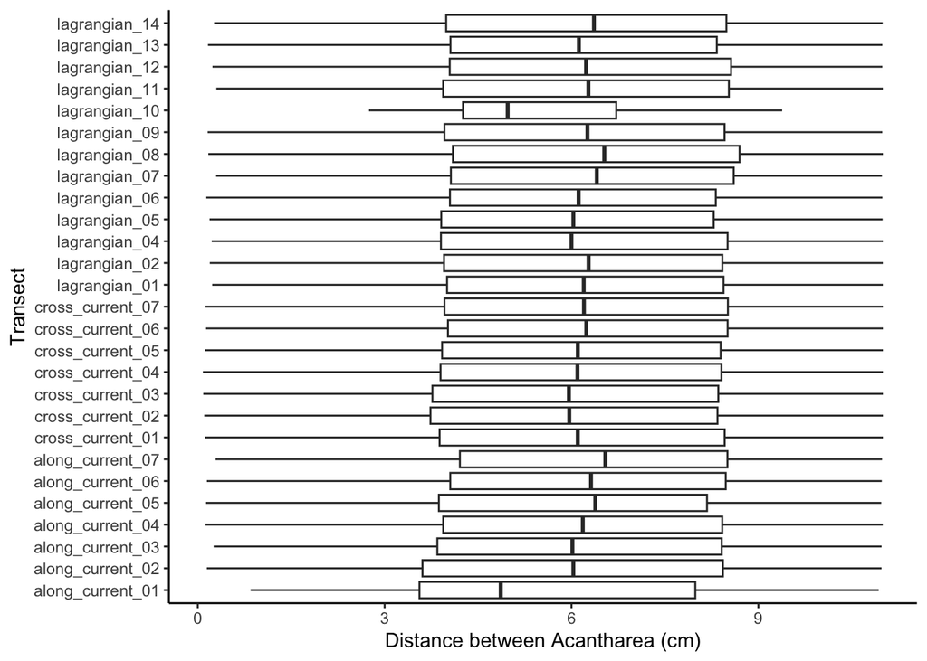

```r
# Read Acantharea distances
file <- "data/distances/02b.intra_distances_Acantharea.parquet"
df <- read_parquet(file)

## Filter distances
# True distances
dist <- df %>% select(img_name, dist) %>% filter(dist < dist_thr)
# Random distances
rand_dist <- df %>% select(img_name, rand_dist) %>% filter(rand_dist < dist_thr)

# Plot distribution of distances per transect
dist |>
  left_join(images |> select(transect, img_name), by = join_by(img_name)) |>
  ggplot() +
  geom_boxplot(aes(x = dist, y = transect)) +
  labs(x = "Distance between Acantharea (cm)", y = "Transect") +
  theme_classic()
```

Distances are quite similar across transects, with some difference for Lagrangian 10, but this transect was only a few minutes long due to ISIIS malfunction, so this explains different distances. However, this accounts for very few distances in the total dataset.

Let’s still check whether there is a link between the number of objects per image and the distribution of distances.

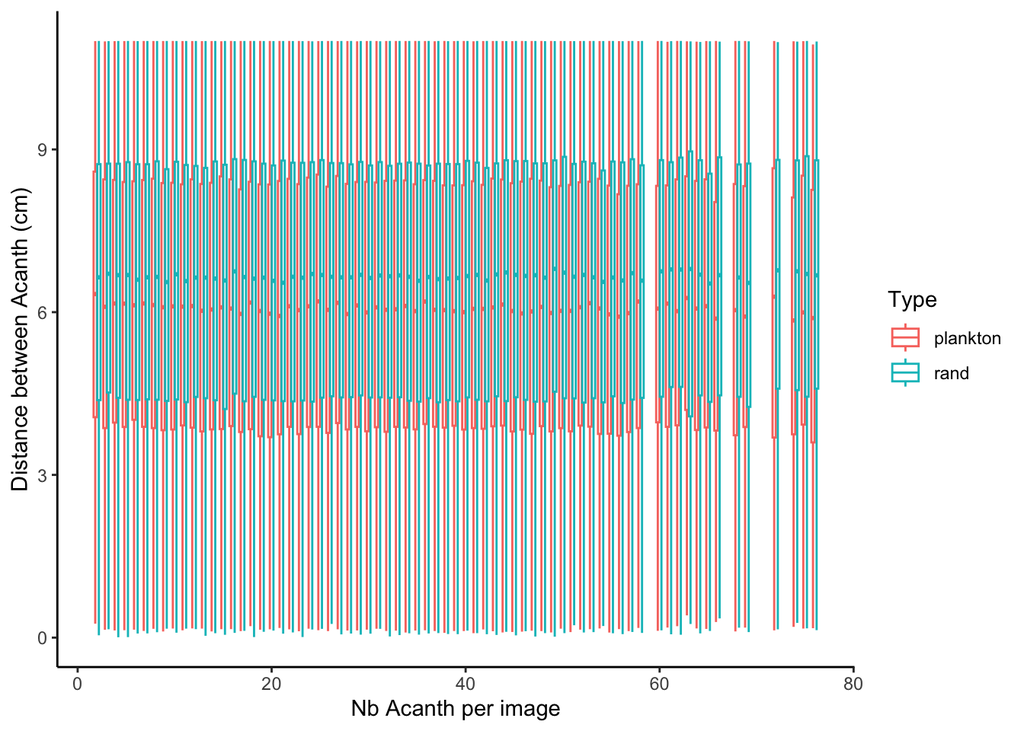

```r
# For each image, plot the distribution of plankton and random distances VS number of objects
bind_rows(
    dist %>% mutate(type = "plankton"),
    rand_dist %>% rename(dist = rand_dist) %>% mutate(type = "rand")
  ) |>
  # join distances with number of objects per image
  left_join(counts, by = join_by(img_name)) |>
  ggplot() +
  geom_boxplot(aes(x = n, y = dist, group = interaction(n, type), colour = type)) +
  labs(x = "Nb Acanth per image", y = "Distance between Acanth (cm)", colour = "Type") +
  theme_classic()
```

There is no link between the number of Acantharea per image and the distance between Acantharea. That may seem counter-intuitive, but actually when adding more objects into an image, it adds both smaller and larger distances, so that the distribution of distances stays the same. On the opposite, the distance to nearest neighbour does decrease.

### Check one patch

Look for one patch in cross current 2.

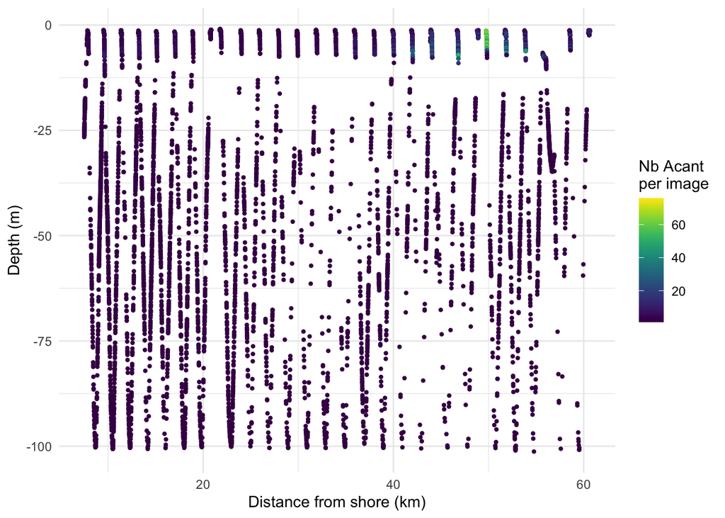

```r
cc2 <- plankton |>
  # keep only objects in CC2
  filter(transect == "cross_current_02") |>
  # count Acant per image
  count(img_name, datetime, lat, lon, dist, depth)

# Plot concentrations along CC2
ggplot(cc2) +
  geom_point(aes(x = dist, y = -depth, colour = n), size = 0.8) +
  scale_colour_viridis_c() +
  labs(x = "Distance from shore (km)", y = "Depth (m)", colour = "Nb Acant\nper image")
```

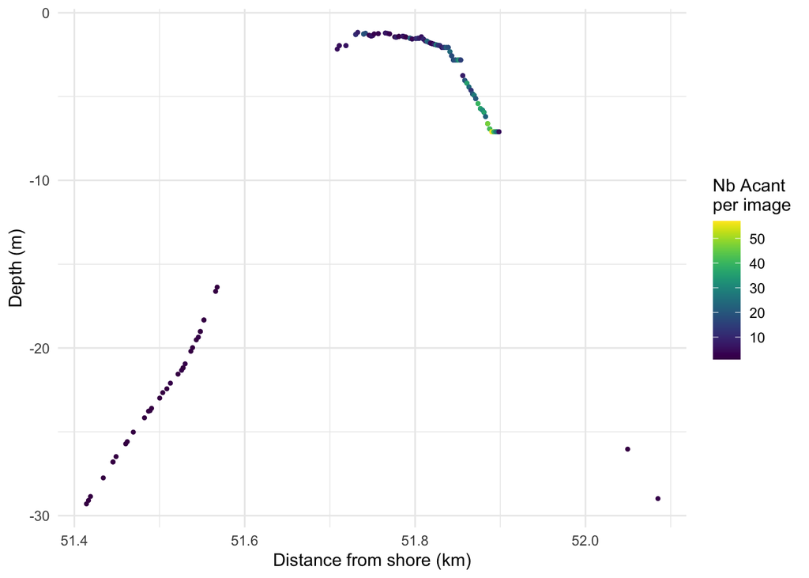

```r
# Let’s zoom in!
ggplot(cc2 |> filter(dist > 51 & dist < 52.5 & depth < 30)) +
  geom_point(aes(x = dist, y = -depth, colour = n), size = 0.8) +
  scale_colour_viridis_c() +
  labs(x = "Distance from shore (km)", y = "Depth (m)", colour = "Nb Acant\nper image")
```

Let’s check distances within this patch.

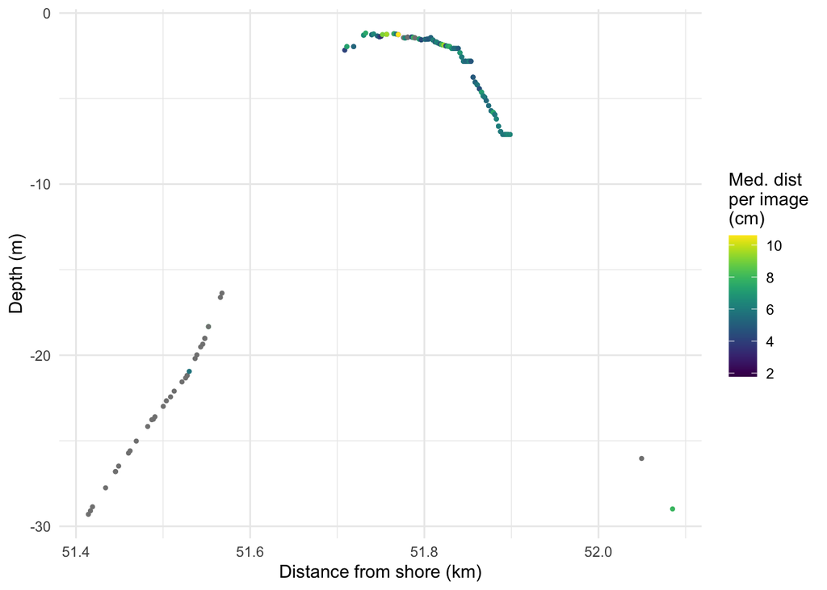

```r
# Compute median distance per image
dist_img <- dist |>
  group_by(img_name) |>
  summarise(med_dist = median(dist))

# Join with image metadata
cc2_dist <- cc2 |>
  filter(dist > 51 & dist < 52.5 & depth < 30) |>
  rename(dist_shore = dist) |>
  left_join(dist_img, by = join_by(img_name))

# Plot median distance in transect (across patch)
ggplot(cc2_dist) +
  geom_point(aes(x = dist_shore, y = -depth, colour = med_dist), size = 0.8) +
  scale_colour_viridis_c() +
  labs(x = "Distance from shore (km)", y = "Depth (m)", colour = "Med. dist\nper image\n(cm)")
```

As expected, median distances are not smaller within the Acantharea patch.

**Note**

Acantharea patches do not influence the distribution of distances between Acantharea.

## Look for classification mistakes

Let’s also check that distances observed between Acantharea are not caused by classification mistakes, e.g. dead particles or noise classified as Acantharea. That said, given the results above, segmentation and classification artefacts should not affect distances, provided that these are isotropic. Let’s still have a look at Acantharea vignettes, focusing on cross current transects.

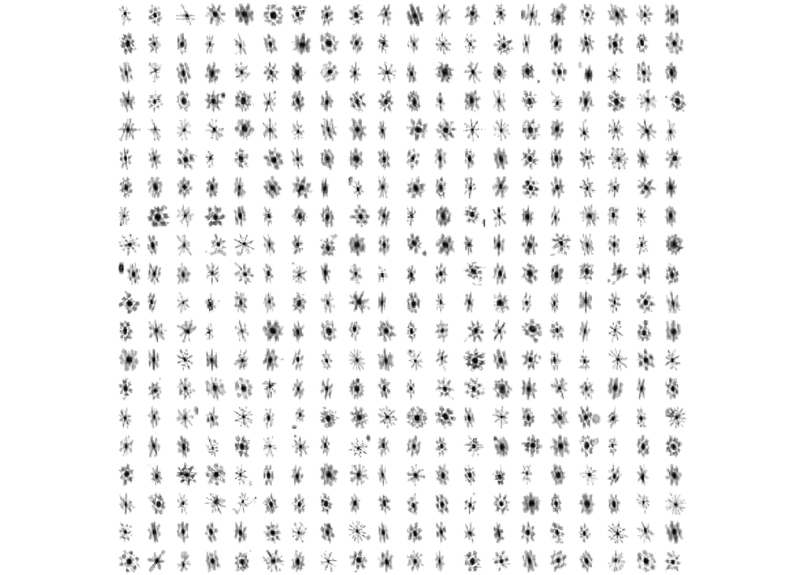

```r
set.seed(123)
sample_img <- counts |>
  # keep images in a few CC transects
  filter(transect %in% c("cross_current_02", "cross_current_03", "cross_current_04", "cross_current_05")) |>
  # keep images with more than 20 objects
  filter(n > 20) |>
  # randomly choose 5 image per transect
  group_by(transect) |>
  slice_sample(n = 5) |>
  ungroup()
# NB notice the timestamps of images: many were collected at very similar times, suggesting sampling across Acantharea patches
# Get particles for these images from Marie at LOV

# Get Acanth from these images in the dataset
sample_acant <- plankton |> filter(img_name %in% sample_img$img_name)

# Compute path to vignette from image name and object id
sample_acant <- sample_acant |>
  mutate(path_to_img = paste0("data/raw/test_acant/", img_name, "/", object_id, ".png"))

# And finally generate a mosaic of 20×20
p_acant <- create_image_mosaic(sample_acant, mosaic_size = 20)
p_acant
```

On the 400 displayed objects, maybe 1 or 2 could be something else that Acantharea, thus the precision in this is > 99%. This means that observed distances are not generated by segmentation or classification artifacts.

**Note**

In conclusion, shorter distances observed between Acantharea are not caused by patches / thin layers, neither by segmentation or classification artifacts.